# Benchmark

Andrea Dalseno

2/19/2021

## Loading the data

On the [data download page](https://www.drivendata.org/competitions/66/flu-shot-learning/data/), we provide everything you need to get started:

- **Training Features**: These are the input variables that your model will use to predict the probability that people received H1N1 flu and seasonal flu vaccines. There are 35 feature columns in total, each a response to a survey question. These questions cover several different topics, such as whether people observed safe behavioral practices, their opinions about the diseases and the vaccines, and their demographics. Check out the [problem description](https://www.drivendata.org/competitions/66/flu-shot-learning/page/211/) page for more information.
- **Training Labels**: These are the labels corresponding to the observations in the training features. There are two target variables: `h1n1_vaccine` and `seasonal_vaccine`. Both are binary variables, with 1 indicating that a person received the respective flu vaccine and 0 indicating that a person did not receive the respective flu vaccine. Note that this is what is known as a “multilabel” modeling task.
- **Test Features**: These are the features for observations that you will use to generate the submission predictions after training a model. We don’t give you the labels for these samples—it’s up to you to generate them.
- **Submission Format**: This file serves as an example for how to format your submission. It contains the index and columns for our submission prediction. The two target variable columns are filled with 0.5 and 0.7 as an example. Your submission to the leaderboard must be in this exact format (with different prediction values) in order to be scored successfully!

Let’s start by importing the libraries that we will need to load and explore the data.

```r
library(tidyverse)
library(kableExtra)
library(rlang)
library(janitor)
```

Next, we can load the datasets and begin taking a look.

```r
features_df <- read.csv('training_set_features.csv', header=TRUE, row.names="respondent_id")

labels_df <- read.csv('training_set_labels.csv', header=TRUE, row.names="respondent_id")
```

```r
sprintf("features_df rows: %i, columns %i", nrow(features_df), ncol(features_df))
```

```
## [1] "features_df rows: 26707, columns 35"
```

```r
head(features_df)%>%
  kbl() %>%
  kable_material(c("striped", "hover"))
```

|  | h1n1_concern | h1n1_knowledge | behavioral_antiviral_meds | behavioral_avoidance | behavioral_face_mask | behavioral_wash_hands | behavioral_large_gatherings | behavioral_outside_home | behavioral_touch_face | doctor_recc_h1n1 | doctor_recc_seasonal | chronic_med_condition | child_under_6_months | health_worker | health_insurance | opinion_h1n1_vacc_effective | opinion_h1n1_risk | opinion_h1n1_sick_from_vacc | opinion_seas_vacc_effective | opinion_seas_risk | opinion_seas_sick_from_vacc | age_group | education | race | sex | income_poverty | marital_status | rent_or_own | employment_status | … |
| --- | --- | --- | --- | --- | --- | --- | --- | --- | --- | --- | --- | --- | --- | --- | --- | --- | --- | --- | --- | --- | --- | --- | --- | --- | --- | --- | --- | --- | --- | --- |
| 0 | 1 | 0 | 0 | 0 | 0 | 0 | 0 | 1 | 1 | 0 | 0 | 0 | 0 | 0 | 1 | 3 | 1 | 2 | 2 | 1 | 2 | 55 - 64 Years | < 12 Years | White | Female | Below Poverty | Not Married | Own | Not in Labor Force | … |
| 1 | 3 | 2 | 0 | 1 | 0 | 1 | 0 | 1 | 1 | 0 | 0 | 0 | 0 | 0 | 1 | 5 | 4 | 4 | 4 | 2 | 4 | 35 - 44 Years | 12 Years | White | Male | Below Poverty | Not Married | Rent | Employed | … |
| 2 | 1 | 1 | 0 | 1 | 0 | 0 | 0 | 0 | 0 | NA | NA | 1 | 0 | 0 | NA | 3 | 1 | 1 | 4 | 1 | 2 | 18 - 34 Years | College Graduate | White | Male | <= $75,000, Above Poverty | Not Married | Own | Employed | … |
| 3 | 1 | 1 | 0 | 1 | 0 | 1 | 1 | 0 | 0 | 0 | 1 | 1 | 0 | 0 | NA | 3 | 3 | 5 | 5 | 4 | 1 | 65+ Years | 12 Years | White | Female | Below Poverty | Not Married | Rent | Not in Labor Force | … |
| 4 | 2 | 1 | 0 | 1 | 0 | 1 | 1 | 0 | 1 | 0 | 0 | 0 | 0 | 0 | NA | 3 | 3 | 2 | 3 | 1 | 4 | 45 - 54 Years | Some College | White | Female | <= $75,000, Above Poverty | Married | Own | Employed | … |
| 5 | 3 | 1 | 0 | 1 | 0 | 1 | 0 | 0 | 1 | 0 | 1 | 0 | 0 | 0 | NA | 5 | 2 | 1 | 5 | 4 | 4 | 65+ Years | 12 Years | White | Male | <= $75,000, Above Poverty | Married | Own | Employed | … |

```r
#knitr::kable(head(features_df), format = "markdown")
```

Each row is a person who was a survey respondent. The columns are the feature values corresponding to those people. We have 26,707 observations and 35 features.

```r
str(features_df)
```

```
## 'data.frame':    26707 obs. of  35 variables:
##  $ h1n1_concern               : int  1 3 1 1 2 3 0 1 0 2 ...
##  $ h1n1_knowledge             : int  0 2 1 1 1 1 0 0 2 1 ...
##  $ behavioral_antiviral_meds  : int  0 0 0 0 0 0 0 0 0 0 ...
##  $ behavioral_avoidance       : int  0 1 1 1 1 1 0 1 1 1 ...
##  $ behavioral_face_mask       : int  0 0 0 0 0 0 0 0 0 0 ...
##  $ behavioral_wash_hands      : int  0 1 0 1 1 1 0 1 1 0 ...
##  $ behavioral_large_gatherings: int  0 0 0 1 1 0 0 0 1 1 ...
##  $ behavioral_outside_home    : int  1 1 0 0 0 0 0 0 1 0 ...
##  $ behavioral_touch_face      : int  1 1 0 0 1 1 0 1 1 1 ...
##  $ doctor_recc_h1n1           : int  0 0 NA 0 0 0 0 1 0 0 ...
##  $ doctor_recc_seasonal       : int  0 0 NA 1 0 1 0 0 0 0 ...
##  $ chronic_med_condition      : int  0 0 1 1 0 0 0 1 0 1 ...
##  $ child_under_6_months       : int  0 0 0 0 0 0 0 0 0 0 ...
##  $ health_worker              : int  0 0 0 0 0 0 0 0 0 0 ...
```

[output cut: 21 more lines]

Now let’s look at the labels.

```r
sprintf("labels_df rows: %i, columns %i", nrow(labels_df), ncol(labels_df))
```

```
## [1] "labels_df rows: 26707, columns 2"
```

```r
head(labels_df)%>%
  kbl()%>%
    kable_material(c("striped", "hover"))
```

|  | h1n1_vaccine | seasonal_vaccine |
| --- | --- | --- |
| 0 | 0 | 0 |
| 1 | 0 | 1 |
| 2 | 0 | 0 |
| 3 | 0 | 1 |
| 4 | 0 | 0 |
| 5 | 0 | 0 |

We have the same 26,707 observations, and two target variables that we have labels for.

## EXPLORING THE DATA

```r
library(ggplot2)
```

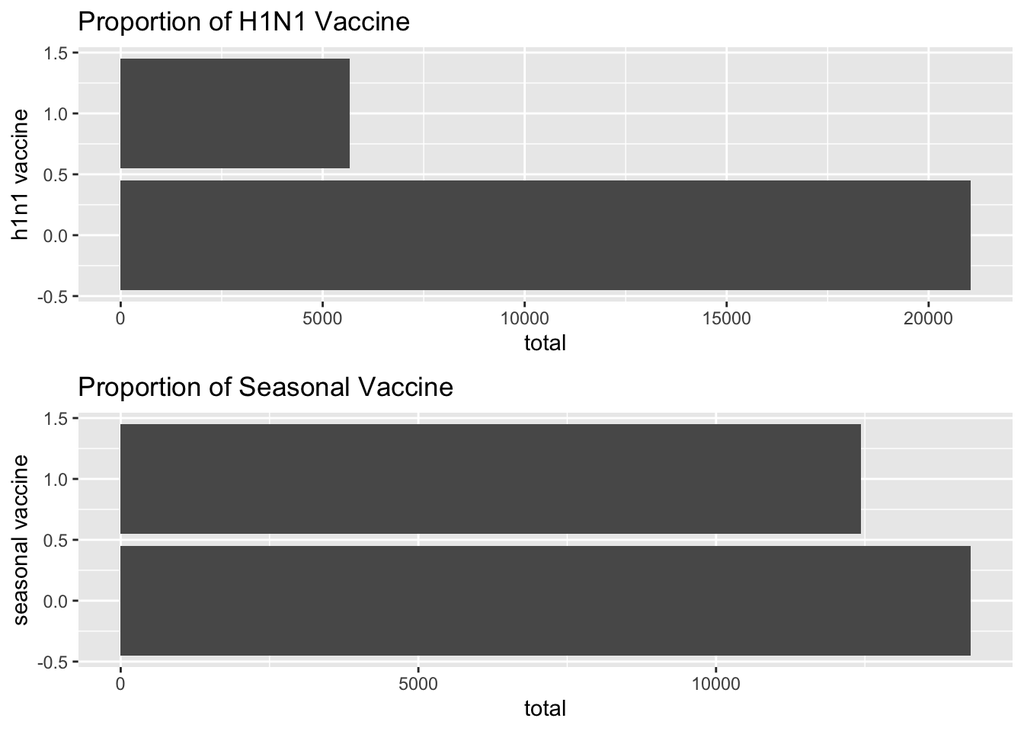

```r
p1 <- labels_df %>%
    group_by(h1n1_vaccine) %>% summarise(total = n()) %>%
ggplot( aes(x=h1n1_vaccine, y=total)) +
  geom_bar(stat='identity') +
  ggtitle("Proportion of H1N1 Vaccine") +
  xlab('h1n1 vaccine')+
  coord_flip()

p2 <- labels_df %>%
    group_by(seasonal_vaccine) %>% summarise(total = n()) %>%
ggplot( aes(x=seasonal_vaccine, y=total)) +
  geom_bar(stat='identity') +
  ggtitle("Proportion of Seasonal Vaccine") +
  xlab('seasonal vaccine')+
  coord_flip()

library(grid)
grid.newpage()
grid.draw(rbind(ggplotGrob(p1), ggplotGrob(p2), size = "last"))
```

It looks like roughy half of people received the seasonal flu vaccine, but only about 20% of people received the H1N1 flu vaccine. In terms of class balance, we say that the seasonal flu vaccine target has balanced classes, but the H1N1 flu vaccine target has moderately imbalanced classes.

Are the two target variables independent? Let’s take a look.

```r
ftable(addmargins(prop.table(table(labels_df))))
```

```
##              seasonal_vaccine          0          1        Sum
## h1n1_vaccine
## 0                             0.49780956 0.28973677 0.78754634
## 1                             0.03658217 0.17587149 0.21245366
## Sum                           0.53439173 0.46560827 1.00000000
```

```r
cor(labels_df$h1n1_vaccine, y = labels_df$seasonal_vaccine, use = "everything",
    method = "pearson")
```

```
## [1] 0.3771427
```

These two variables have a phi coefficient of 0.37, indicating a moderate positive correlation. We can see that in the cross-tabulation as well. Most people who got an H1N1 flu vaccine also got the seasonal flu vaccine. While a minority of people who got the seasonal vaccine got the H1N1 vaccine, they got the H1N1 vaccine at a higher rate than those who did not get the seasonal vaccine.

## Features

Next, let’s take a look at our features. From the problem description page, we know that the feature variables are almost all categorical: a mix of binary, ordinal, and nominal features. Let’s pick a few and see how the rates of vaccination may differ across the levels of the feature variables.

First, let’s combine our features and labels into one dataframe.

```r
joined_df <- transform(merge(features_df,labels_df,by='row.names',all=TRUE), row.names=Row.names, Row.names=NULL)
sprintf("joined_df rows: %i, columns %i", nrow(joined_df), ncol(joined_df))
```

```
## [1] "joined_df rows: 26707, columns 37"
```

```r
head(joined_df)%>%
  kbl()%>%
    kable_material(c("striped", "hover"))
```

|  | h1n1_concern | h1n1_knowledge | behavioral_antiviral_meds | behavioral_avoidance | behavioral_face_mask | behavioral_wash_hands | behavioral_large_gatherings | behavioral_outside_home | behavioral_touch_face | doctor_recc_h1n1 | doctor_recc_seasonal | chronic_med_condition | child_under_6_months | health_worker | health_insurance | opinion_h1n1_vacc_effective | opinion_h1n1_risk | opinion_h1n1_sick_from_vacc | opinion_seas_vacc_effective | opinion_seas_risk | opinion_seas_sick_from_vacc | age_group | education | race | sex | income_poverty | marital_status | rent_or_own | employment_status | … |
| --- | --- | --- | --- | --- | --- | --- | --- | --- | --- | --- | --- | --- | --- | --- | --- | --- | --- | --- | --- | --- | --- | --- | --- | --- | --- | --- | --- | --- | --- | --- |
| 0 | 1 | 0 | 0 | 0 | 0 | 0 | 0 | 1 | 1 | 0 | 0 | 0 | 0 | 0 | 1 | 3 | 1 | 2 | 2 | 1 | 2 | 55 - 64 Years | < 12 Years | White | Female | Below Poverty | Not Married | Own | Not in Labor Force | … |
| 1 | 3 | 2 | 0 | 1 | 0 | 1 | 0 | 1 | 1 | 0 | 0 | 0 | 0 | 0 | 1 | 5 | 4 | 4 | 4 | 2 | 4 | 35 - 44 Years | 12 Years | White | Male | Below Poverty | Not Married | Rent | Employed | … |
| 10 | 2 | 1 | 0 | 1 | 0 | 1 | 1 | 0 | 0 | 0 | 0 | 1 | 1 | 0 | 0 | 4 | 1 | 2 | 5 | 4 | 4 | 45 - 54 Years | 12 Years | White | Male | <= $75,000, Above Poverty | Married | Rent | Employed | … |
| 100 | 2 | 1 | 0 | 1 | 0 | 1 | 0 | 1 | 1 | 1 | 1 | 0 | 0 | 0 | NA | 4 | 3 | 2 | 2 | 3 | 4 | 18 - 34 Years | 12 Years | White | Female | <= $75,000, Above Poverty | Not Married | Rent | Employed | … |
| 1000 | 2 | 2 | 1 | 1 | 0 | 0 | 0 | 0 | 0 | 0 | 0 | 0 | 0 | 0 | 1 | 3 | 3 | 2 | 5 | 3 | 2 | 35 - 44 Years | College Graduate | White | Female | > $75,000 | Married | Own | Employed | … |
| 10000 | 0 | 2 | 0 | 1 | 0 | 1 | 0 | 0 | 1 | 0 | 0 | 0 | 0 | 0 | 1 | 2 | 1 | 1 | 1 | 1 | 1 | 35 - 44 Years | College Graduate | White | Male | > $75,000 | Married | Own | Employed | … |

### Prototyping a Plot

Next, let’s see how the features are correlated with the target variables. We’ll start with trying to visualize if there is simple bivariate correlation. If a feature is correlated with the target, we’d expect there to be different patterns of vaccination as you vary the values of the feature.

Jumping right to the right final visualization is hard. We can instead pick one feature and one target and work our way up to a prototype, before applying it to more features and both targets. We’ll use `h1n1_concern`, the level of concern the person showed about the H1N1 flu, and `h1n1_vaccine` as a target variable.

First, we’ll get the count of observations for each combination of those two variables.

```r
counts <- joined_df %>%
  select(h1n1_concern, h1n1_vaccine)%>%
  group_by(h1n1_concern, h1n1_vaccine)%>%
  summarise(n=n(), .groups = 'drop')%>%
  na.omit() %>%
  pivot_wider(names_from = h1n1_vaccine, values_from = n)%>%
  rename('h1'='1', 'h0'='0')

counts
```

```
## # A tibble: 4 x 3
##   h1n1_concern    h0    h1
##          <int> <int> <int>
## 1            0  2849   447
## 2            1  6756  1397
## 3            2  8102  2473
## 4            3  3250  1341
```

**ggplot prefers a long structure**

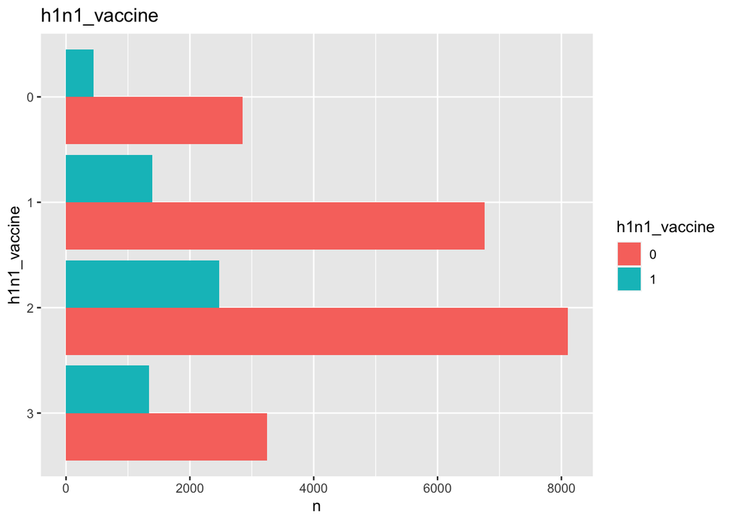

```r
joined_df %>%
  select(h1n1_concern, h1n1_vaccine)%>%
  group_by(h1n1_concern, h1n1_vaccine)%>%
  summarise(n=n())%>%
  na.omit() %>%
  mutate(h1n1_vaccine=as.factor(h1n1_vaccine), h1n1_concern=as.factor(h1n1_concern))%>%
  ggplot(aes(x=reorder(h1n1_concern, desc(h1n1_concern)), y=n, fill=h1n1_vaccine))+
  geom_bar(position="dodge",stat='identity' ) +
  ggtitle("h1n1_vaccine")+
    xlab('h1n1_vaccine')+
    coord_flip()
```

Unfortunately, it’s still hard to tell whether `h1n1_concern` levels show differences in someone’s likelihood to get vaccinated. Since the two classes are imbalanced, we just see fewer vaccinated observations for every level of `h1n1_concern`. It swamps out any other trends that might exist.

Let’s instead look at the **rate** of vaccination for each level of `h1n1_concern`.

```r
h1n1_concern_counts  <-  cbind(counts$h1n1_concern,rowSums(counts))

h1n1_concern_counts
```

```
##      [,1]  [,2]
## [1,]    0  3296
## [2,]    1  8154
## [3,]    2 10577
## [4,]    3  4594
```

```r
props <- counts %>%
  adorn_totals(where='col')%>%
  mutate(h0=h0/Total, h1=h1/Total)%>%
  select(h1n1_concern,h0,h1)

props
```

```
##  h1n1_concern        h0        h1
##             0 0.8643811 0.1356189
##             1 0.8286520 0.1713480
##             2 0.7661466 0.2338534
##             3 0.7079068 0.2920932
```

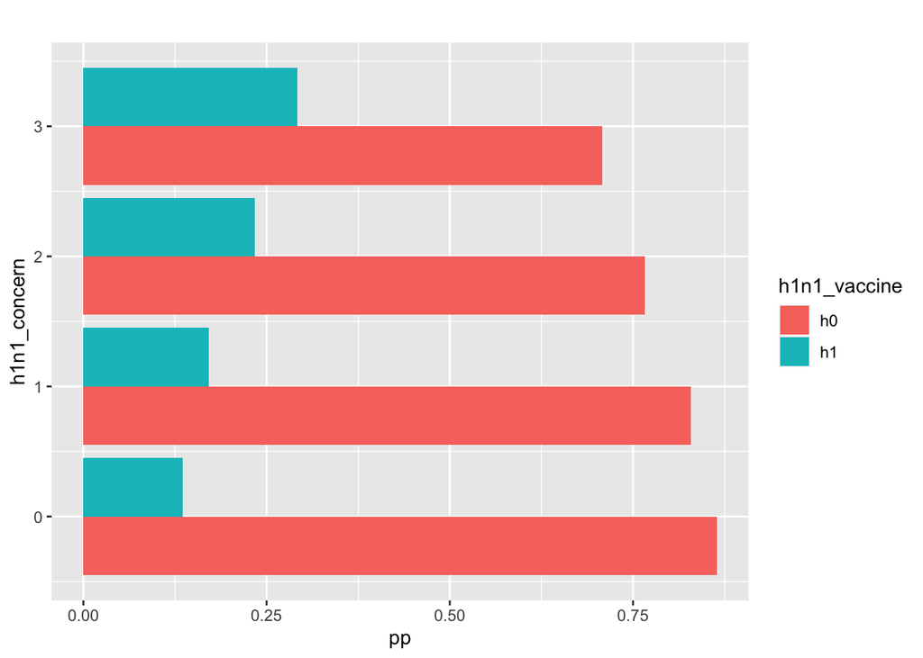

```r
props %>%
  pivot_longer(names_to='h1n1_vaccine', cols=!h1n1_concern, values_to = 'pp')%>%
  ggplot(aes(x=h1n1_concern, y=pp, fill=h1n1_vaccine))+
  geom_bar(position="dodge",stat='identity' ) +
  ggtitle("")+
    xlab('h1n1_concern')+
    coord_flip()
```

Since every pair of bars adds up to 1.0 and we only have two bars, this is actually a good use case for a stacked bar chart, to make it even easier to read.

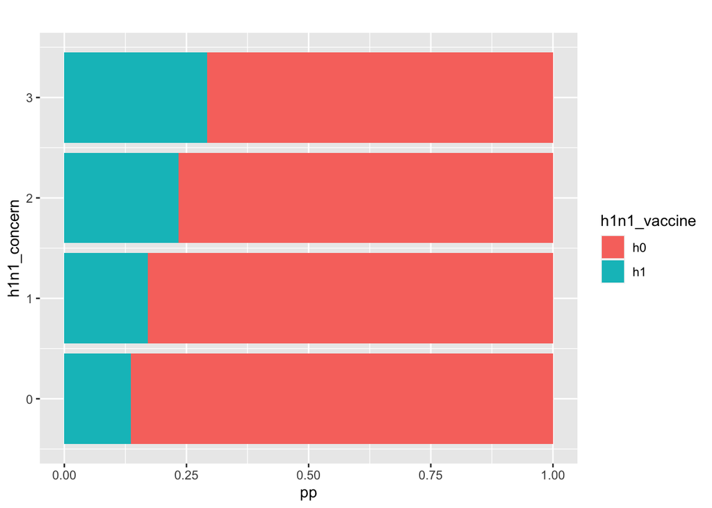

```r
props %>%
  pivot_longer(names_to='h1n1_vaccine', cols=!h1n1_concern, values_to = 'pp')%>%
  ggplot(aes(x=h1n1_concern, y=pp, fill=h1n1_vaccine))+
  geom_bar(position="stack",stat='identity' ) +
  ggtitle("")+
    xlab('h1n1_concern')+
    coord_flip()
```

This is a more compact plot showing the same thing as before.

### Plotting more variables

Let’s factor this code into a function so we can use it on more variables.

```r
vaccination_rate_plot <-  function(column, target, df ) {

  # Stacked bar chart of vaccination rate for `target` against
  #   `column`.
  #
  #   Args:
  #       column (string): column name of feature variable
  #       target (string): column name of target variable
  #       df (pandas DataFrame): dataframe that contains columns
  #           `col` and `target`
  #       returns a ggplot
  column <- sym(column)
  target <- ensym(target)
   counts <-  df%>%
     select(!!column, !!target)%>%
     group_by(!!column, !!target)%>%
     summarise(n=n(), .groups = 'drop')%>%
     na.omit()%>%
     pivot_wider(names_from = !!target, values_from = n)%>%
     rename('h1'='1', 'h0'='0')



   props <- counts %>%
  adorn_totals(where='col')%>%
  mutate(h0=h0/Total, h1=h1/Total)%>%
  select(!!column,h0,h1)


   p3 <- props %>%
  pivot_longer(names_to=as_string(target), cols=-1, values_to = 'pp')%>%
  ggplot(aes(x=!!column, y=pp, fill=!!target))+
  geom_bar(position="stack",stat='identity' ) +
  ggtitle("")+
    xlab({{column}})+
    ylab('')+
    coord_flip()


}
```

Then, we’ll loop through several columns and plot against both `h1n1_vaccine` and `seasonal_vaccine`.

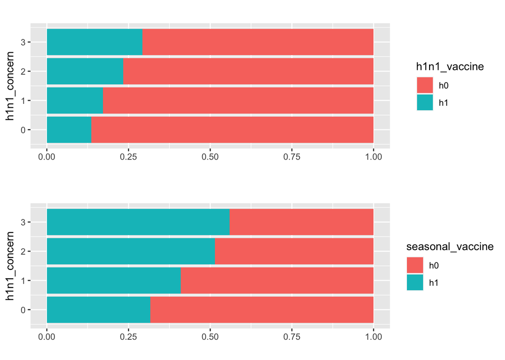

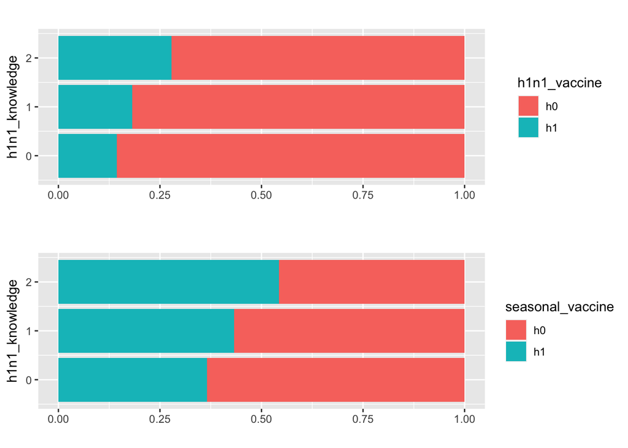

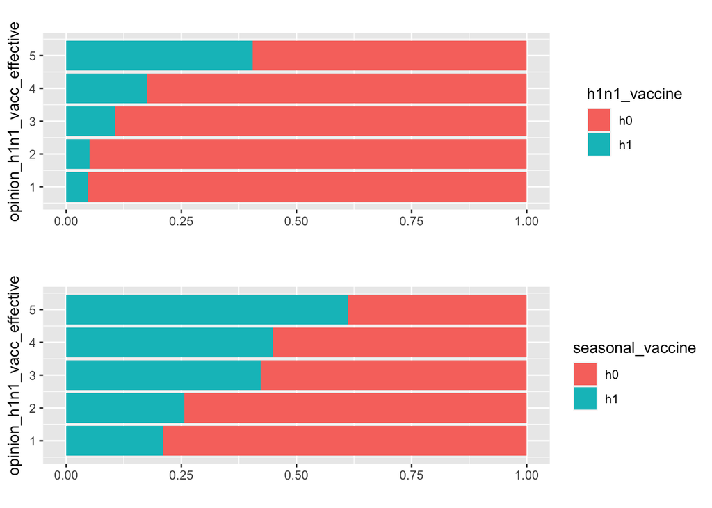

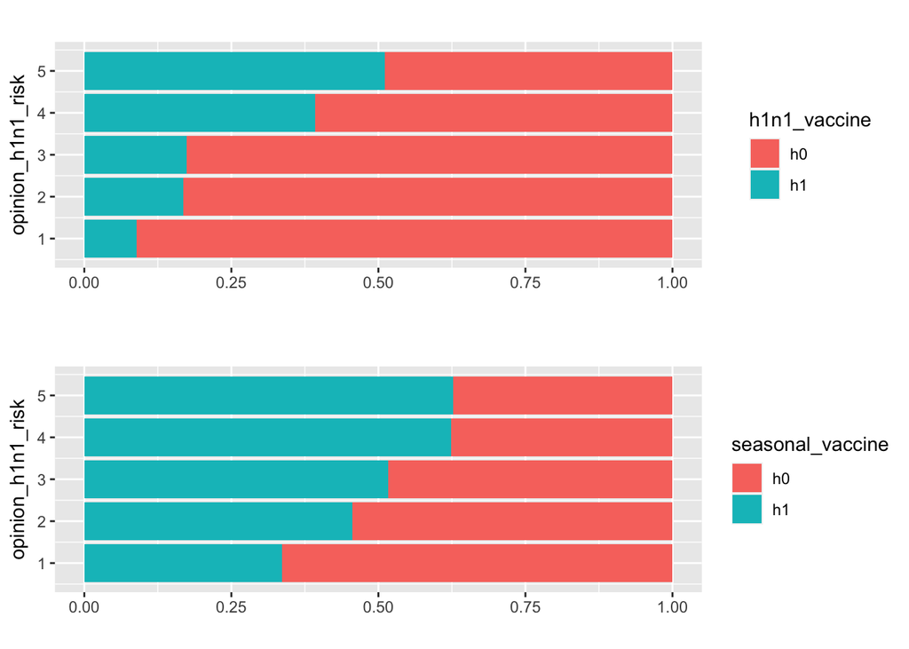

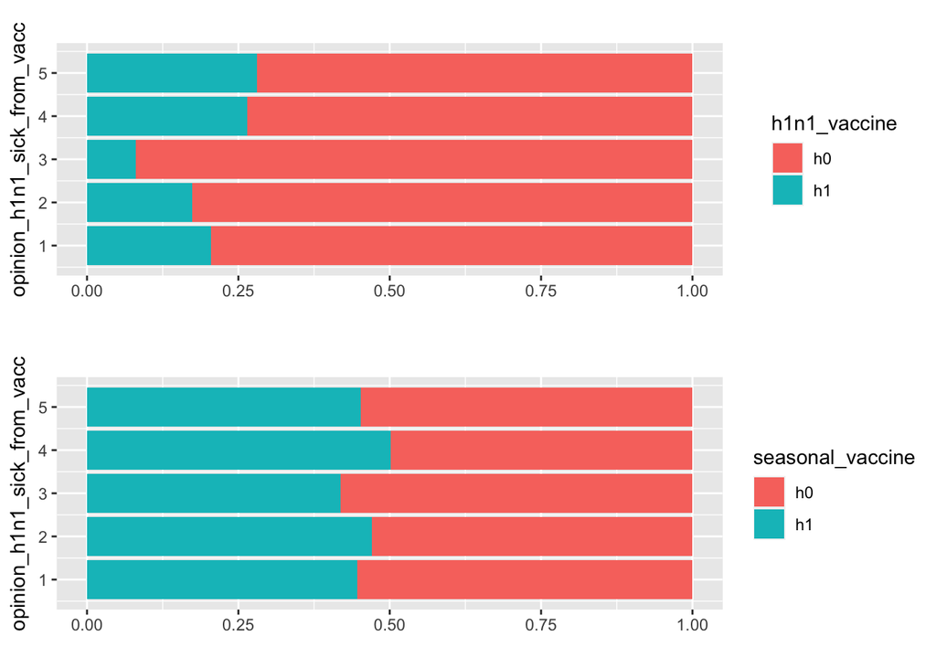

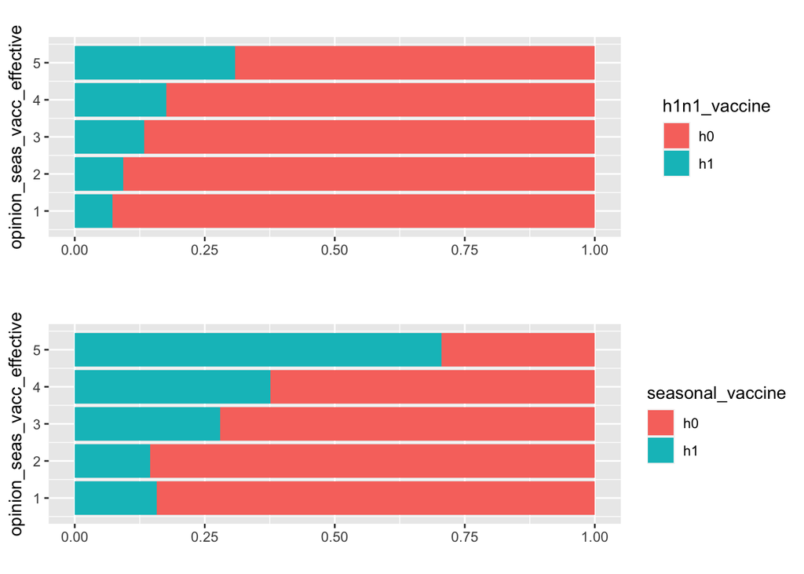

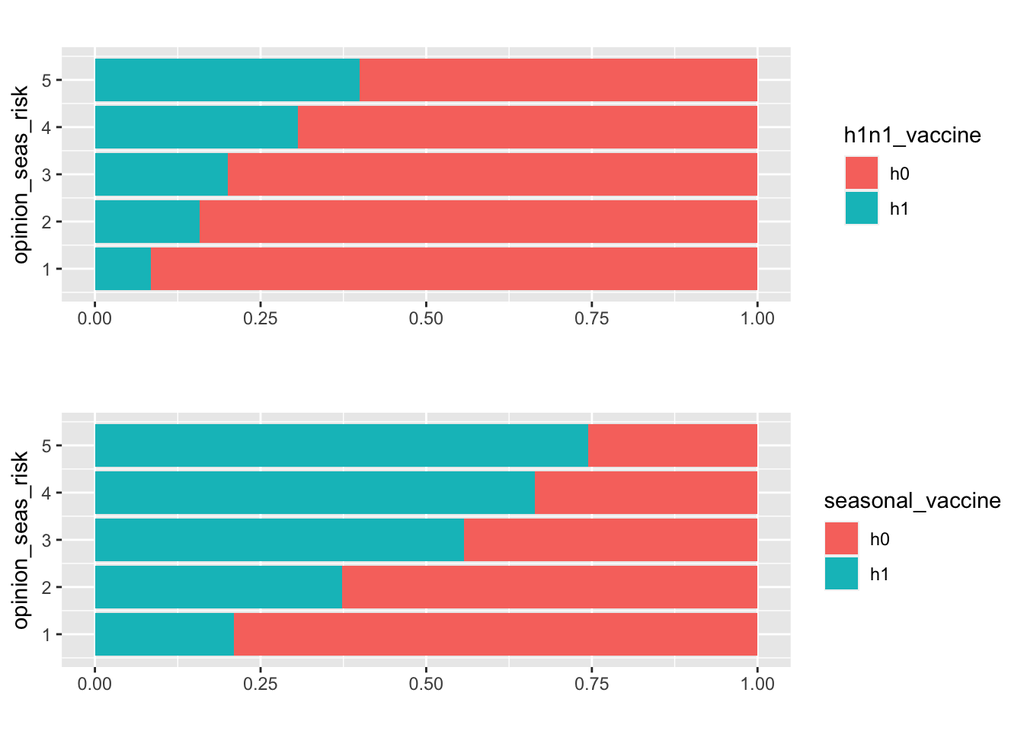

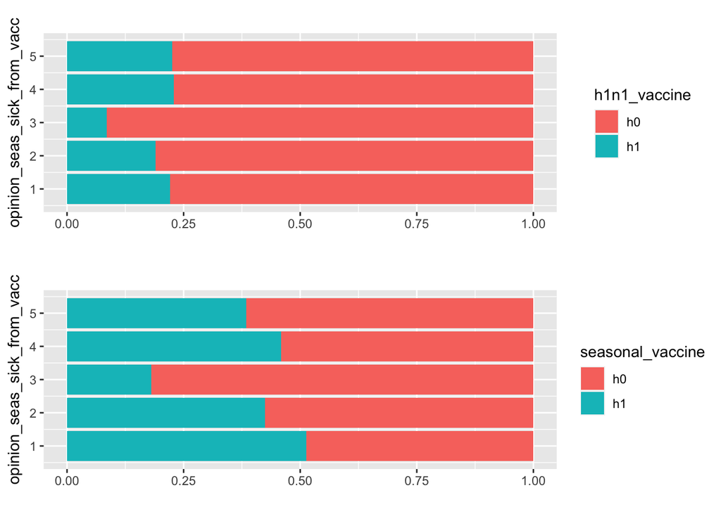

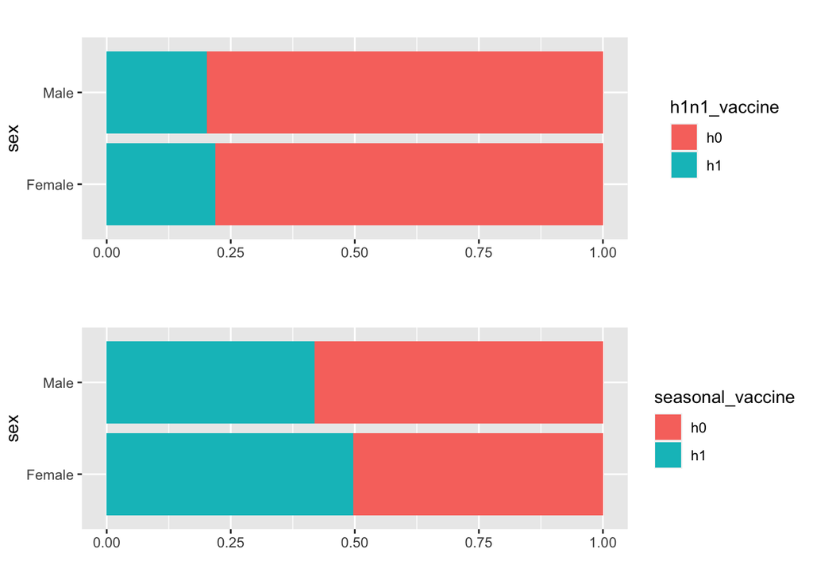

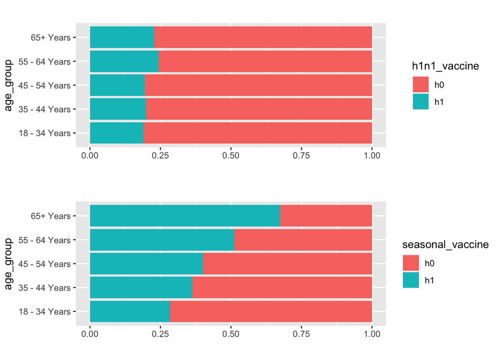

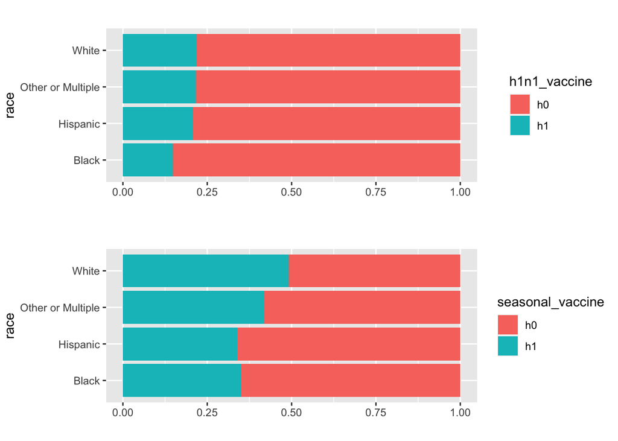

```r
cols_to_plot = c(
    'h1n1_concern',
    'h1n1_knowledge',
    'opinion_h1n1_vacc_effective',
    'opinion_h1n1_risk',
    'opinion_h1n1_sick_from_vacc',
    'opinion_seas_vacc_effective',
    'opinion_seas_risk',
    'opinion_seas_sick_from_vacc',
    'sex',
    'age_group',
    'race'
)
for (i in  cols_to_plot){
  tmp1 <- vaccination_rate_plot(i, 'h1n1_vaccine', joined_df)
  tmp2 <- vaccination_rate_plot(i, 'seasonal_vaccine', joined_df)
  grid.newpage()
grid.draw(rbind(ggplotGrob(tmp1), ggplotGrob(tmp2), size = "last"))
}
```

It looks like the knowledge and opinion questions have pretty strong signal for both target variables.

The demographic features have stronger correlation with `seasonal_vaccine`, but much less so far `h1n1_vaccine`. In particular, we interestingly see a strong correlation with `age_group` with the `seasonal_vaccine` but not with `h1n1_vaccine`. It appears that with seasonal flu, people act appropriately according to the fact that people [more impacted and have higher risk of flu-related complications with age](https://www.cdc.gov/flu/highrisk/index.htm). It turns out though that H1N1 flu has an interesting relationship with age: [even though older people have higher risk of complications, they were less likely to get infected!](https://www.cdc.gov/h1n1flu/surveillanceqa.htm#7) While we know anything about causality from this analysis, it seems like the risk factors ended up being reflected in the vaccination rates.

## Building some models

Let’s start working on training some models! We will be using logistic regression, a simple and fast linear model for classification problems. Logistic regression is a great model choice for a first-pass baseline model when starting out on a problem.

Standard logistic regression only works with numeric input for features. Since this is a benchmark, we’re going to build simple models only using the numeric columns of our dataset.

Categorical variables with non-numeric values take a little more preprocessing to prepare for many machine learning algorithms. We’re not going to deal with them in this benchmark walkthrough, but there are many different ways to encode categorical variables into numeric values. Check out [one-hot encoding](https://scikit-learn.org/stable/modules/generated/sklearn.preprocessing.OneHotEncoder.html) and [ordinal encoding](https://scikit-learn.org/stable/modules/generated/sklearn.preprocessing.OrdinalEncoder.html) to get started if you’re not familiar.

```r
for (i in colnames(features_df)){
  if (class(features_df[[i]]) != 'character'){
    print(i)
  }
}
```

```
## [1] "h1n1_concern"
## [1] "h1n1_knowledge"
## [1] "behavioral_antiviral_meds"
## [1] "behavioral_avoidance"
## [1] "behavioral_face_mask"
## [1] "behavioral_wash_hands"
## [1] "behavioral_large_gatherings"
## [1] "behavioral_outside_home"
## [1] "behavioral_touch_face"
## [1] "doctor_recc_h1n1"
## [1] "doctor_recc_seasonal"
## [1] "chronic_med_condition"
## [1] "child_under_6_months"
## [1] "health_worker"
## [1] "health_insurance"
## [1] "opinion_h1n1_vacc_effective"
## [1] "opinion_h1n1_risk"
## [1] "opinion_h1n1_sick_from_vacc"
## [1] "opinion_seas_vacc_effective"
## [1] "opinion_seas_risk"
## [1] "opinion_seas_sick_from_vacc"
## [1] "household_adults"
## [1] "household_children"
```

```r
numeric_cols <- c()
for (i in colnames(features_df)){
  if (class(features_df[[i]]) != 'character'){
    numeric_cols <-  rbind(numeric_cols,i)
  }
}
numeric_cols <- as.vector(numeric_cols)
```

## Feature-Preprocessing

```r
library(scales)
scaled_df <- joined_df%>%
  select(c(numeric_cols,c('h1n1_vaccine', 'seasonal_vaccine')))%>%
  sapply(function(.) rescale(.))
```

```
## Note: Using an external vector in selections is ambiguous.
## ℹ Use `all_of(numeric_cols)` instead of `numeric_cols` to silence this message.
## ℹ See <https://tidyselect.r-lib.org/reference/faq-external-vector.html>.
```

```r
scaled_df <- as.data.frame(scaled_df)%>%
  mutate_all(~ifelse(is.na(.), median(., na.rm=TRUE), .))
```

Next, we’re going to define our estimators.

## Estimator

```r
# Logistics Regression
#model <- glm(Survived ~.,family=binomial(link='logit'),data=train)
```

## Training and Evaluation

Finally, let’s get ready to train and evaluate our model.

```r
library(caTools)
set.seed(101)
sample = sample.split(scaled_df$h1n1_concern, SplitRatio = .70)
train = subset(scaled_df, sample == TRUE)
test  = subset(scaled_df, sample == FALSE)
```

Now, let’s train the model!

```r
model.h1 <- glm(h1n1_vaccine~.-seasonal_vaccine,family=binomial(link='logit'),data=train)
model.se <- glm(seasonal_vaccine~.-h1n1_vaccine,family=binomial(link='logit'),data=train)
```

Make predictions

```r
h1n1.probs = predict(model.h1, type='response', newdata=test)
se.probs = predict(model.se, type='response', newdata=test)
```

This competition uses [ROC AUC](https://towardsdatascience.com/understanding-auc-roc-curve-68b2303cc9c5) as the metric. Let’s plot ROC curves and take a look. Unfortunately, scikit-learn’s convenient [`plot_roc_curve`](https://scikit-learn.org/stable/modules/generated/sklearn.metrics.plot_roc_curve.html) doesn’t support multilabel, so we’ll need to make the plot ourselves.

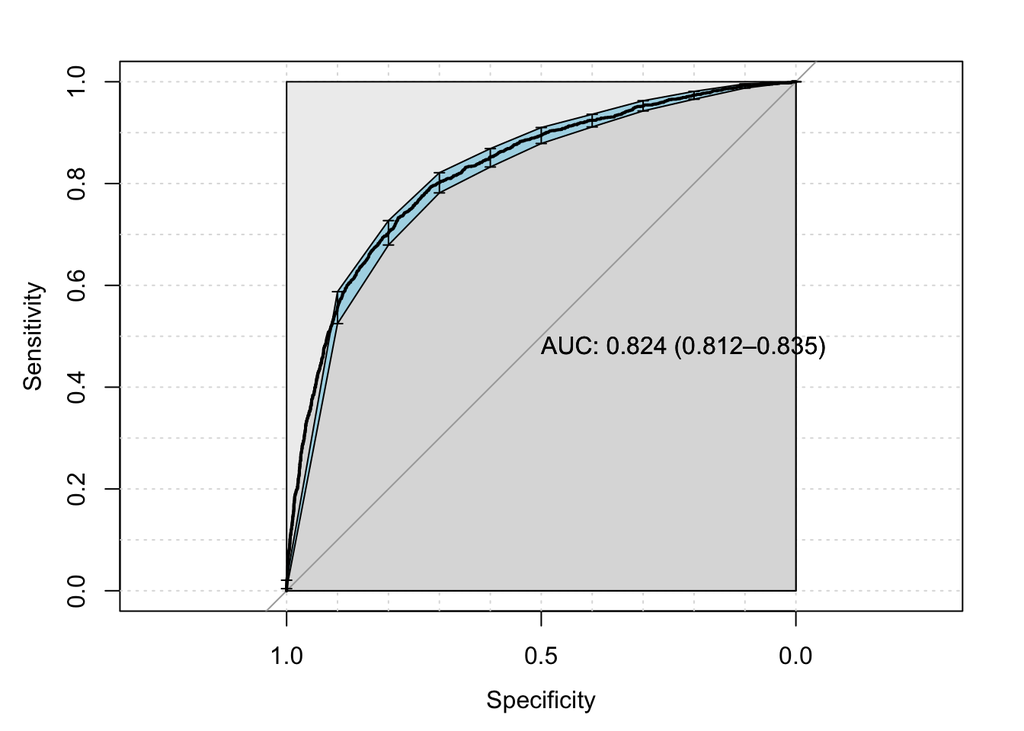

```r
library(pROC)
pROC_obj <- roc(test$h1n1_vaccine,h1n1.probs,
            smoothed = TRUE,
            # arguments for ci
            ci=TRUE, ci.alpha=0.9, stratified=FALSE,
            # arguments for plot
            plot=TRUE, auc.polygon=TRUE, max.auc.polygon=TRUE, grid=TRUE,
            print.auc=TRUE, show.thres=TRUE)
sens.ci <- ci.se(pROC_obj)
plot(sens.ci, type="shape", col="lightblue")
## Warning in plot.ci.se(sens.ci, type = "shape", col = "lightblue"): Low
## definition shape.
plot(sens.ci, type="bars")
```

```r
auc(pROC_obj)
```

```
## Area under the curve: 0.8239
```

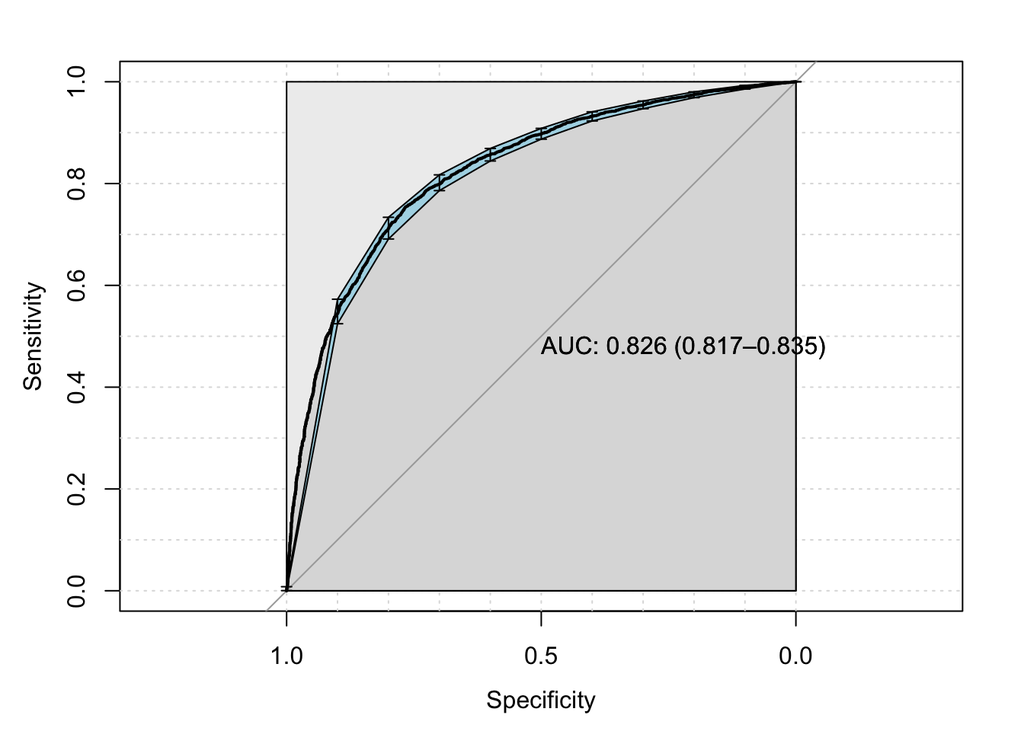

```r
pROC_obj <- roc(test$seasonal_vaccine,se.probs,
            smoothed = TRUE,
            # arguments for ci
            ci=TRUE, ci.alpha=0.9, stratified=FALSE,
            # arguments for plot
            plot=TRUE, auc.polygon=TRUE, max.auc.polygon=TRUE, grid=TRUE,
            print.auc=TRUE, show.thres=TRUE)
sens.ci <- ci.se(pROC_obj)
plot(sens.ci, type="shape", col="lightblue")
## Warning in plot.ci.se(sens.ci, type = "shape", col = "lightblue"): Low
## definition shape.
plot(sens.ci, type="bars")
```

```r
auc(pROC_obj)
```

```
## Area under the curve: 0.8265
```

An AUC score of 0.5 is no better than random, and an AUC score of 1.0 is a perfect model. Both models look like they generally perform similarly. Our scores of around 0.83 are not great, but they’re not bad either!

## Retrain Model on Full Dataset

Now that we have an idea of our performance, we’ll want to retrain our model on the full dataset before generating our predictions on the test set.

```r
scaled_df.h1 <- scaled_df%>%
  select(-seasonal_vaccine)
scaled_df.se <- scaled_df%>%
  select(-h1n1_vaccine)
```

```r
final_model.h1 <- glm(h1n1_vaccine~.,family=binomial(link='logit'),data=scaled_df.h1)
final_model.se <- glm(seasonal_vaccine~.,family=binomial(link='logit'),data=scaled_df.se)
```

```r
test_df <- read.csv('test_set_features.csv', header=TRUE, row.names="respondent_id")
```

```r
scaled_test <- test_df%>%
  select(c(numeric_cols))%>%
  sapply(function(.) rescale(.))

scaled_test <- as.data.frame(scaled_test)%>%
  mutate_all(~ifelse(is.na(.), median(., na.rm=TRUE), .))
```

```r
test_probas.h1 = predict(final_model.h1, type = 'response', newdata = scaled_test)
test_probas.se = predict(final_model.se, type = 'response', newdata = scaled_test)
```

Let’s read in the submission format file so we can put our predictions into it.

```r
submission_df <- read.csv('submission_format.csv', header=TRUE, row.names="respondent_id")
```

```r
head(submission_df)%>%
  kbl()%>%
    kable_material(c("striped", "hover"))
```

|  | h1n1_vaccine | seasonal_vaccine |
| --- | --- | --- |
| 26707 | 0.5 | 0.7 |
| 26708 | 0.5 | 0.7 |
| 26709 | 0.5 | 0.7 |
| 26710 | 0.5 | 0.7 |
| 26711 | 0.5 | 0.7 |
| 26712 | 0.5 | 0.7 |

```r
# identical here won't work since test_probas.h1 is a vector. Just check the both have the same lenght
assertthat::are_equal(nrow(submission_df), length(test_probas.h1))
```

```
## [1] TRUE
```

```r
assertthat::are_equal(nrow(submission_df), length(test_probas.se))
```

```
## [1] TRUE
```

```r
# Save predictions to submission data frame
submission_df[["h1n1_vaccine"]] = test_probas.h1
submission_df[["seasonal_vaccine"]] = test_probas.se
```

```r
head(submission_df)%>%
  kbl()%>%
    kable_material(c("striped", "hover"))
```

|  | h1n1_vaccine | seasonal_vaccine |
| --- | --- | --- |
| 26707 | 0.1271857 | 0.4263852 |
| 26708 | 0.0552250 | 0.0711914 |
| 26709 | 0.3709951 | 0.6373900 |
| 26710 | 0.4644162 | 0.8035037 |
| 26711 | 0.2866966 | 0.6349586 |
| 26712 | 0.4078874 | 0.8903622 |

```r
# Transform row names in column and convert it to integer (otherwise they will be strings)
library(data.table)
setDT(submission_df, keep.rownames = 'respondent_id')[]
```

```
##        respondent_id h1n1_vaccine seasonal_vaccine
##     1:         26707   0.12718570       0.42638524
##     2:         26708   0.05522500       0.07119144
##     3:         26709   0.37099508       0.63738997
##     4:         26710   0.46441624       0.80350373
##     5:         26711   0.28669664       0.63495863
##    ---
## 26704:         53410   0.36071643       0.57252018
## 26705:         53411   0.06418098       0.24047221
## 26706:         53412   0.19592593       0.40127892
## 26707:         53413   0.05071380       0.31996117
## 26708:         53414   0.61609438       0.64208452
```

```r
submission_df <- submission_df %>%
  mutate(respondent_id=as.integer(respondent_id))
```

```r
write.csv(submission_df,"submission.csv", row.names = FALSE)
```

## Submit to the Leaderboard

We can then head over to the competition [submissions page](https://www.drivendata.org/competitions/66/flu-shot-learning/submissions/) to submit the predictions.

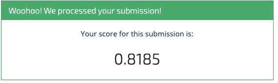

Done!